# GSE75010_merged_analysis

Kyle Campbell

10/20/2020

```r
merged <- readRDS(paste0(data_dir, "GSE75010_merged_abundances2020-10-21.rda"))
```

Run Levene’s test for homogeneity of variance.

```r
leveneTest(ga ~ batch, data = merged)
```

```
## Levene's Test for Homogeneity of Variance (center = median)
##        Df F value    Pr(>F)
## group   7  25.594 < 2.2e-16 ***
##       322
## ---
## Signif. codes:  0 '***' 0.001 '**' 0.01 '*' 0.05 '.' 0.1 ' ' 1
```

table1 r package to do descriptive statistics https://cran.r-project.org/web/packages/table1/vignettes/table1-examples.html

Need to create an empty stratum for the variable you want to test by.

```r
t1 <- merged
t1$phenotype <- factor(t1$phenotype, levels = c("C", "PE", "99"), labels = c("Control", "Preeclampsia", "P-value"))
t1$sex <- factor(t1$sex, levels = c("F", "M"), labels = c("Female", "Male"))

label(t1$phenotype) <- "Preeclampsia"
label(t1$sex) <- "Sex"
label(t1$batch) <- "Study"
label(t1$ga) <- "Gestational Age"

units(t1$ga) <- "wks"
```

```r
View(t1)
```

Custom code from the package authors to add p-value column. An empty stratum called P-value is required for the variable you are testing. rndr function will need to be adpated to each specific situation, including the entering the dataframe you wish to use and the statistical test to use for numeric and non-numeric columns. rndr.strat does not need to be modified. https://cran.r-project.org/web/packages/table1/vignettes/table1-examples.html#a-column-of-p-values

```r
rndr <- function(x, name, ...) {
    if (length(x) == 0) {
        # RHS needs to correspond to the dataframe you input to t1()
        y <- t1[[name]]
        s <- rep("", length(render.default(x=y, name=name, ...)))
        if (is.numeric(y)) {
            # RHS needs to correspond to the dataframe you input to t1()
            # If the column is numeric, set the desired statistical test, T-test here
            p <- t.test(y ~ t1$phenotype)$p.value
        } else {
            #Again droplevels() argument needs to be the dataframe you input to t1()
            # If the column is not numeric, set the desired statistical test, Chi-square here
            p <- chisq.test(table(y, droplevels(t1$phenotype)))$p.value
        }
        s[2] <- sub("<", "&lt;", format.pval(p, digits=3, eps=0.001))
        s
    } else {
        render.default(x=x, name=name, ...)
    }
}

rndr.groups <- function(x, name, ...) {
    if (length(x) == 0) {
        # RHS needs to correspond to the dataframe you input to t1()
        y <- t1[[name]]
        s <- rep("", length(render.default(x=y, name=name, ...)))
        if (is.numeric(y)) {
            # RHS needs to correspond to the dataframe you input to t1()
            # If the column is numeric, set the desired statistical test, Kruskal-Wallis here
            p <- kruskal.test(y ~ t1$batch)$p.value
        } else {
            #Again droplevels() argument needs to be the dataframe you input to t1()
            # If the column is not numeric, set the desired statistical test, Chi-square here
            p <- chisq.test(table(y, droplevels(t1$batch)))$p.value
        }
        s[2] <- sub("<", "&lt;", format.pval(p, digits=3, eps=0.001))
        s
    } else {
        render.default(x=x, name=name, ...)
    }
}

rndr.strat <- function(label, n, ...) {
    ifelse(n==0, label, render.strat.default(label, n, ...))
}
```

Bivariate outcome with t-test for continuous variables and Chi-square test for categorical outcomes.

```r
table1(~ sex + ga + batch | phenotype, data=t1, droplevels=F, render=rndr, render.strat=rndr.strat, overall=F)
```

|  | Control (N=173) | Preeclampsia (N=157) | P-value |
| --- | --- | --- | --- |
| Sex |  |  |  |
| Female | 78 (45.1%) | 81 (51.6%) | 0.284 |
| Male | 95 (54.9%) | 76 (48.4%) |  |
| Gestational Age (wks) |  |  |  |
| Mean (SD) | 35.2 (3.97) | 33.0 (3.17) | <0.001 |
| Median [Min, Max] | 37.0 [25.0, 41.0] | 33.0 [25.0, 39.0] |  |
| Study |  |  |  |
| GSE10588 | 26 (15.0%) | 17 (10.8%) | 0.393 |
| GSE24129 | 8 (4.6%) | 8 (5.1%) |  |
| GSE25906 | 37 (21.4%) | 23 (14.6%) |  |
| GSE30186 | 6 (3.5%) | 6 (3.8%) |  |
| GSE43942 | 7 (4.0%) | 5 (3.2%) |  |
| GSE44711 | 8 (4.6%) | 8 (5.1%) |  |
| GSE4707 | 4 (2.3%) | 10 (6.4%) |  |
| GSE75010 | 77 (44.5%) | 80 (51.0%) |  |

Bivariate batch with Kruskal-Wallis ANOVA (regular ANOVA homogeneity of variances violated) for continuous variables and Chi-square test for categorical outcomes.

```r
t1$phenotype <- droplevels(t1$phenotype)
label(t1$phenotype) <- "Preeclampsia"
t1$batch <- factor(t1$batch, levels = append(levels(t1$batch), "99"), labels = append(levels(t1$batch), "P-value"))

table1(~ sex + ga + phenotype | batch, data=t1, droplevels=F, render=rndr.groups, render.strat=rndr.strat, overall=F)
```

|  | GSE10588 (N=43) | GSE24129 (N=16) | GSE25906 (N=60) | GSE30186 (N=12) | GSE43942 (N=12) | GSE44711 (N=16) | GSE4707 (N=14) | GSE75010 (N=157) | P-value |
| --- | --- | --- | --- | --- | --- | --- | --- | --- | --- |
| Sex |  |  |  |  |  |  |  |  |  |
| Female | 22 (51.2%) | 6 (37.5%) | 29 (48.3%) | 7 (58.3%) | 8 (66.7%) | 6 (37.5%) | 7 (50.0%) | 74 (47.1%) | 0.798 |
| Male | 21 (48.8%) | 10 (62.5%) | 31 (51.7%) | 5 (41.7%) | 4 (33.3%) | 10 (62.5%) | 7 (50.0%) | 83 (52.9%) |  |
| Gestational Age (wks) |  |  |  |  |  |  |  |  |  |
| Mean (SD) | 34.0 (0) | 34.5 (3.61) | 36.4 (3.17) | 37.5 (1.57) | 37.3 (2.06) | 31.9 (3.59) | 33.0 (0) | 33.1 (4.25) | <0.001 |
| Median [Min, Max] | 34.0 [34.0, 34.0] | 34.5 [31.0, 38.0] | 37.0 [27.0, 40.0] | 37.5 [36.0, 39.0] | 39.0 [35.0, 39.0] | 32.5 [25.0, 37.0] | 33.0 [33.0, 33.0] | 33.0 [25.0, 41.0] |  |
| Preeclampsia |  |  |  |  |  |  |  |  |  |
| Control | 26 (60.5%) | 8 (50.0%) | 37 (61.7%) | 6 (50.0%) | 7 (58.3%) | 8 (50.0%) | 4 (28.6%) | 77 (49.0%) | 0.393 |
| Preeclampsia | 17 (39.5%) | 8 (50.0%) | 23 (38.3%) | 6 (50.0%) | 5 (41.7%) | 8 (50.0%) | 10 (71.4%) | 80 (51.0%) |  |

```r
t1$batch <- droplevels(t1$batch)
label(t1$batch) <- "Batch"
```

Custom function to graph variables by group via Violin Plot.

```r
# DATA: dataframe that contains data of interest
# GROUP: MUST be character vector
# VARIABLES: MUST be character vector
violin_compare_groups <- function(data, group, variables) {
  violins <- list()
  for(variable in variables) {
      violins[[variable]] <- ggplot(data, aes(.data[[group]], .data[[variable]])) + geom_violin()
  }
  return(violins)
}
cell.types <- colnames(merged)[6:19]
violins <- violin_compare_groups(merged, "phenotype", cell.types)
```

Convert to long data format for graphing purposes

```r
# Remove the unnecessary columns
# Select was masked, had to add dplyr::
merged.violin <- merged %>% dplyr::select(!c(batch, ga, sex, p_value, correlation, rmse))

long <- gather(merged.violin, cell_type, proportion, fibroblasts:extravillous_trophoblasts, factor_key = F)
long.placenta <- long %>%
  dplyr::filter(cell_type %in% c("fibroblasts", "cytotrophoblasts", "hofbauer_cells", "endothelial_cells", "synctyiotrophoblast", "npicytotrophoblasts", "extravillous_trophoblasts"))
long.immune <- long %>%
  dplyr::filter(!cell_type %in% c("fibroblasts", "cytotrophoblasts", "hofbauer_cells", "endothelial_cells", "synctyiotrophoblast", "npicytotrophoblasts", "extravillous_trophoblasts"))
```

scale = “width” argument required rather than ggplot2 default of scale = “area” for this dataset TODO cleanup x-axis label

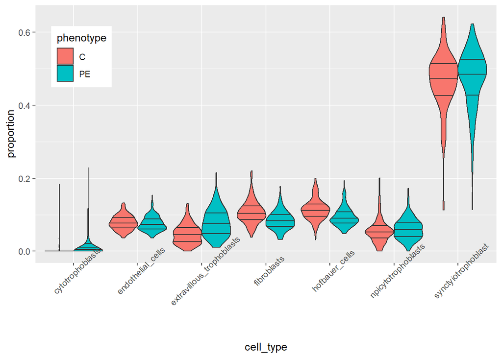

```r
ggplot(long.placenta, aes(x = cell_type, y = proportion, fill = phenotype)) + geom_violin(scale = "width", draw_quantiles = c(0.25, 0.5, 0.75)) + theme(legend.position = c(.1, .8)) + theme(axis.text.x = element_text(angle = 45))
```

```r
#ggsave(paste0(data_dir, "vln_placenta.png"), device = png())
```

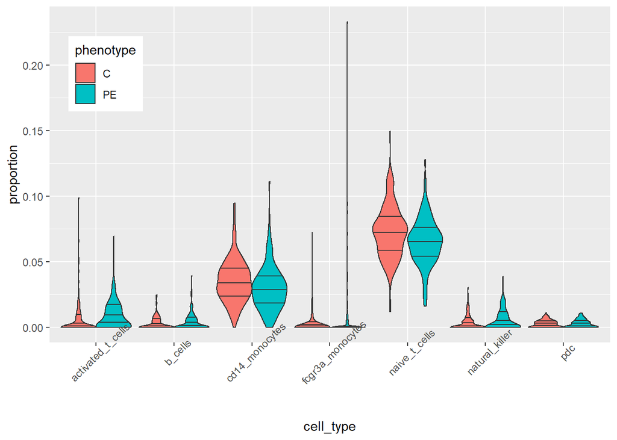

```r
ggplot(long.immune, aes(x = cell_type, y = proportion, fill = phenotype)) + geom_violin(scale = "width", draw_quantiles = c(0.25, 0.5, 0.75)) + theme(legend.position = c(.1, .8)) + theme(axis.text.x = element_text(angle = 45))
```

```r
#ggsave(paste0(data_dir, "vln_immune.png"), device = png())
```

Beta transformation function to accomodate 0’s in the cell types where 0’s are predicted.

```r
beta_transform <- function(x, n) {
  return((1/n)*(x*(n-1)+0.5))
}
```

Function to run beta regressions over the outcomes of interest.

```r
# run beta regression models with multiple outcomes, the same set of covariates, and a dataset that includes all outcomes and covariates.
# outcomes is a character vector
# covariates is a character vector
# data is a 2d dataframe suitable for regression
beta_reg_models <- function(outcomes, covariates, data) {
  # Initialize empty list to store fitted regression models
  models <- list()
  # Loop over outcomes of interest
  for(outcome in outcomes) {
    # transform the data to accomodate 0s for beta regression if necessary
    if (0 %in% data[, outcome]) {
      data[, outcome] <- beta_transform(data[, outcome], nrow(data))
    }
    formula <- as.formula(
      paste0(outcome, " ~ ", paste(covariates, collapse = " + "))
    )
    models[[outcome]] <- tidy(x = betareg(formula = formula, data = data), data = data, conf.int = TRUE, conf.level = .95)
  }
  return(models)
}

# Same function as above but returns model fit statistics
beta_reg_model_fits <- function(outcomes, covariates, data) {
  # Initialize empty list to store fitted regression models
  model_fits <- list()
  # Loop over outcomes of interest
  for(outcome in outcomes) {
    # transform the data to accomodate 0s for beta regression if necessary
    if (0 %in% data[, outcome]) {
      data[, outcome] <- beta_transform(data[, outcome], nrow(data))
    }
    formula <- as.formula(
      paste0(outcome, " ~ ", paste(covariates, collapse = " + "))
    )
    model_fits[[outcome]] <- glance(x = betareg(formula = formula, data = data), data = data)
  }
  return(model_fits)
}
```

Run a model across all the cell types. TODO Model Fit Statistics, low pseudo-r-sq, possibly precision parameter optimization required?

```r
# Set the covariates vector, including the exposure at the front
covariates <- c("phenotype", "sex", "ga", "batch")
models <- beta_reg_models(cell.types, covariates, merged)
fits <- beta_reg_model_fits(cell.types, covariates, merged)
```

Comparing fixed precision parameter, Phi, against variable precision parameter modeled with all covariates.

```r
# Fixed dispersion
#mod <- betareg(as.formula(paste0("fibroblasts", " ~ ", paste(covariates, collapse = " + "))), data = merged)
# Variable dispersion model with all covariates, sex and phenotype not significant, some batch dummies are significant
#mod2 <- betareg(as.formula(paste0("fibroblasts", " ~ ", paste(covariates, collapse = " + "), " | ", paste(covariates, collapse = " + "))), #data = merged)
#lrtest(mod, mod2)
```

Model fit diagnostics plots can be accessed with plot.

```r
#plot(mod)
```

Pull all model effect estimates and combine to a single tibble for graphing.

```r
pull_estimates <- function(data) {
  return(
    data %>%
      filter(term == "phenotypePE") %>%
      dplyr::select(estimate,
                    conf.low,
                    conf.high,
                    p.value) %>%
      mutate(
        or = exp(estimate),
        lower = exp(conf.low),
        upper = exp(conf.high)
      )
  )
}
estimates <- lapply(X = models, FUN = pull_estimates)
# Collapse list of model estimates to a single tibble
estimates <- Reduce(rbind, estimates)
# Add cell_type names and reorganize columns
estimates <-
  estimates %>%
  mutate(cell_type = names(models)) %>%
  dplyr::select(cell_type, everything())
#write.csv(estimates, paste0(data_dir, "model_data.csv"))
```

John’s Forest plot code

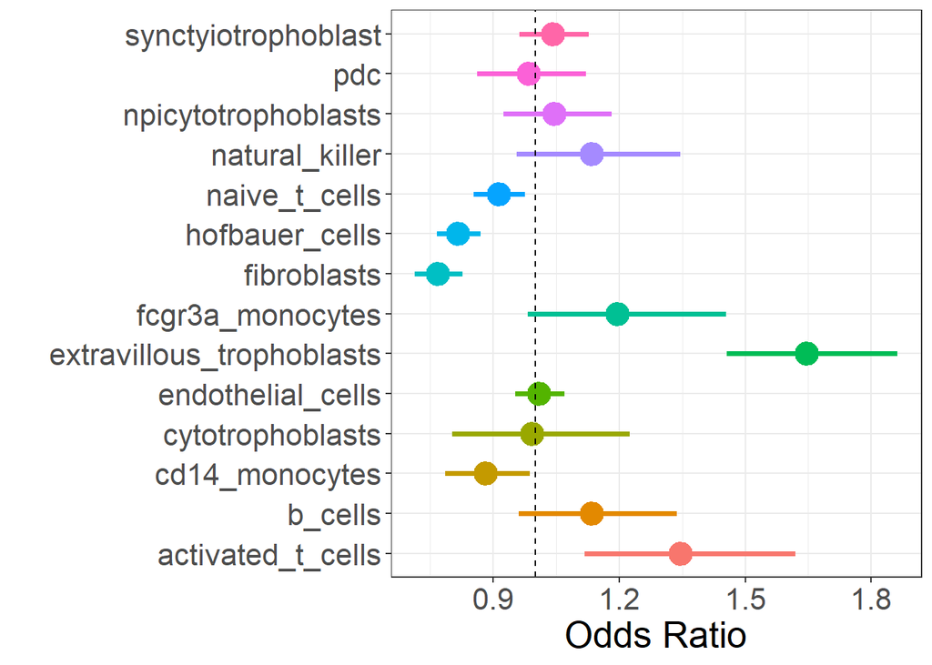

```r
forest <- ggplot(data=estimates,
                       aes(x=cell_type, y=or, ymin=lower, ymax=upper)) +
    geom_pointrange(aes(col=cell_type), position=position_dodge2(width=1), size=1.3) +
    geom_hline(yintercept=1, linetype=2) +
    theme_bw() +
    theme(text = element_text(size=20),
          legend.position = 'none') +
    xlab('') + ylab('Odds Ratio') +
    coord_flip()
#ggsave(paste0(data_dir, "forest.png"), device = png())
forest
```